# Náhodná veličina: Cvičení

Kateřina Večerková vecerkok@vscht.cz

2025-06-26

# Cvičení

## **Cvičení 1: Simulace nefér mince**

Simulujte 1000 hodů nefér mincí, kde pravděpodobnost padnutí orla je 0,7. Vypočítejte a vykreslete pravděpodobnostní funkci (PMF) pro počet orlů.

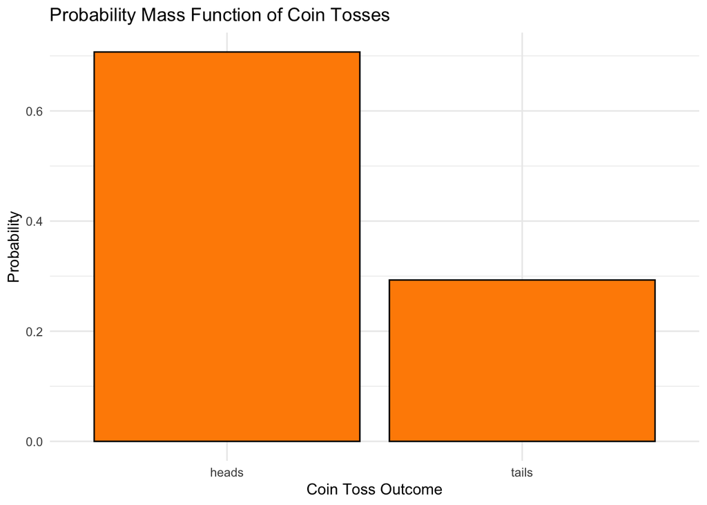

```r
set.seed(42)
library(ggplot2)

# simulate coin tosses
coin_tosses <- sample(c("heads", "tails"), size = 1000, replace = TRUE, prob = c(0.7, 0.3))

# plot PMF
coin_tosses_table <- table(coin_tosses)
coin_tosses_data <- as.data.frame(coin_tosses_table)
colnames(coin_tosses_data) <- c("coin_toss", "frequency")
coin_tosses_data$coin_toss <- as.factor(coin_tosses_data$coin_toss)
coin_tosses_data$probability <- coin_tosses_data$frequency / sum(coin_tosses_data$frequency)

ggplot(coin_tosses_data, aes(x = coin_toss, y = probability)) +
  geom_bar(stat = "identity", fill = "darkorange", color = "black") +
  labs(title = "Probability Mass Function of Coin Tosses",
       x = "Coin Toss Outcome",
       y = "Probability") +
  theme_minimal()
```

## **Cvičení 2: Distribuční funkce (CDF) pro nefér minci**

Použijte výsledek z Cvičení 1, vypočítejte a vykreslete distribuční funkci (CDF) pro počet orlů z 1000 hodů nefér mincí.

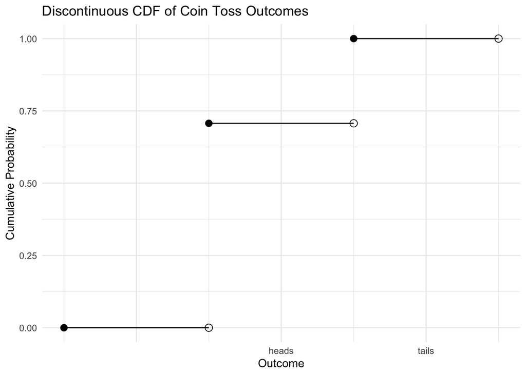

```r
set.seed(42)
# compute cumulative probabilities
cdf <- cumsum(coin_tosses_table) / sum(coin_tosses_table)

# Add a zero-probability point
cdf <- c(0, cdf)
outcomes <- c("Start", names(coin_tosses_table))  # add a label for the zero point

# create a data frame for plotting
cdf_df <- data.frame(
  outcome = names(cdf),
  cumulative_probability = as.numeric(cdf)
)

# convert outcome to factor and use numeric positions for x
cdf_df$numeric_outcome <- seq_along(cdf_df$outcome)

# plot using ggplot2
ggplot(cdf_df, aes(x = numeric_outcome, y = cumulative_probability)) +
  # horizontal lines for steps
  geom_segment(
    aes(x = numeric_outcome - 0.5, xend = numeric_outcome + 0.5,
        y = cumulative_probability, yend = cumulative_probability),
    color = "black"
  ) +
  # filled points at the left end
  geom_point(
    aes(x = numeric_outcome - 0.5, y = cumulative_probability),
    size = 3, color = "black", shape = 16  # filled circle
  ) +
  # hollow points at the right end
  geom_point(
    aes(x = numeric_outcome + 0.5, y = cumulative_probability),
    size = 3, color = "black", shape = 1  # hollow circle
  ) +
  # customize x-axis labels
  scale_x_continuous(breaks = cdf_df$numeric_outcome, labels = cdf_df$outcome) +
  labs(
    title = "Discontinuous CDF of Coin Toss Outcomes",
    x = "Outcome",
    y = "Cumulative Probability"
  ) +
  theme_minimal() +
  scale_y_continuous(limits = c(0, 1))  # ensure y-axis spans from 0 to 1
```

## **Cvičení 3: Vlastní diskrétní náhodná veličina – Počet gólů ve fotbalovém zápase**

Předpokládejme, že fotbalový tým dává 0 až 4 góly za zápas s následujícími pravděpodobnostmi:

- 0 gólů: 0.2
- 1 gól: 0.3
- 2 góly: 0.25
- 3 góly: 0.15
- 4 góly: 0.1

Napište kód pro reprezentaci této diskrétní náhodné veličiny. Poté vypočítejte a vykreslete její PMF a CDF.

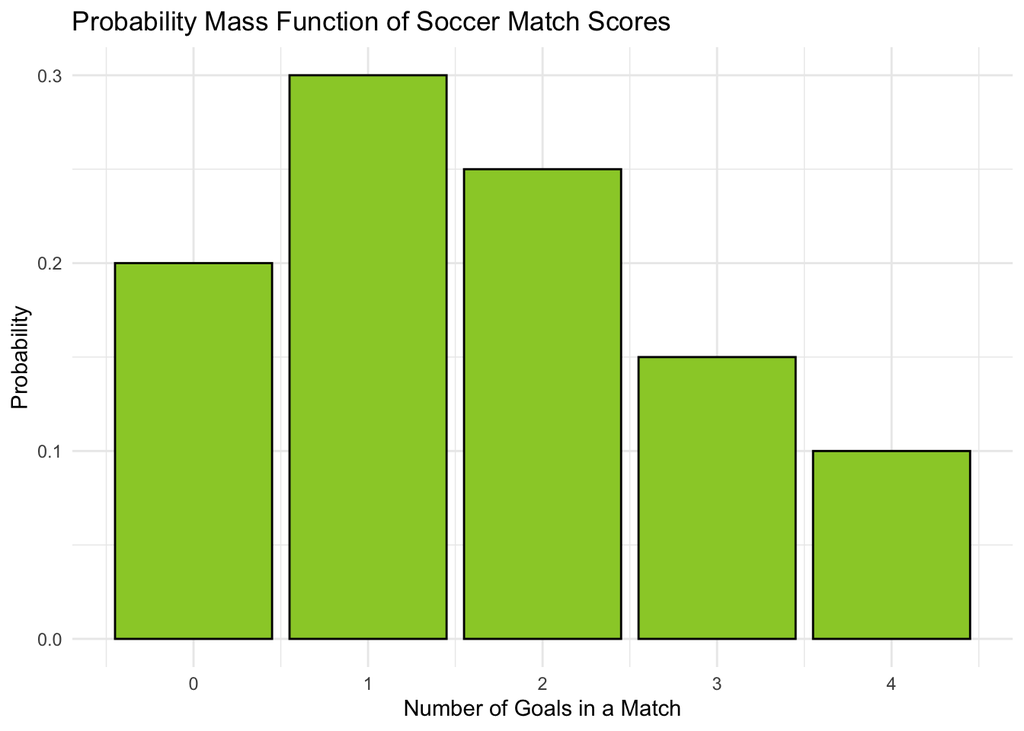

```r
set.seed(42)
scores <- data.frame(number_of_goals = c(0:4), probability = c(0.2, 0.3, 0.25, 0.15, 0.1))
# plot PMF
ggplot(scores, aes(x = number_of_goals, y = probability)) +
  geom_bar(stat = "identity", fill = "yellowgreen", color = "black") +
  labs(title = "Probability Mass Function of Soccer Match Scores",
       x = "Number of Goals in a Match",
       y = "Probability") +
  theme_minimal()
```

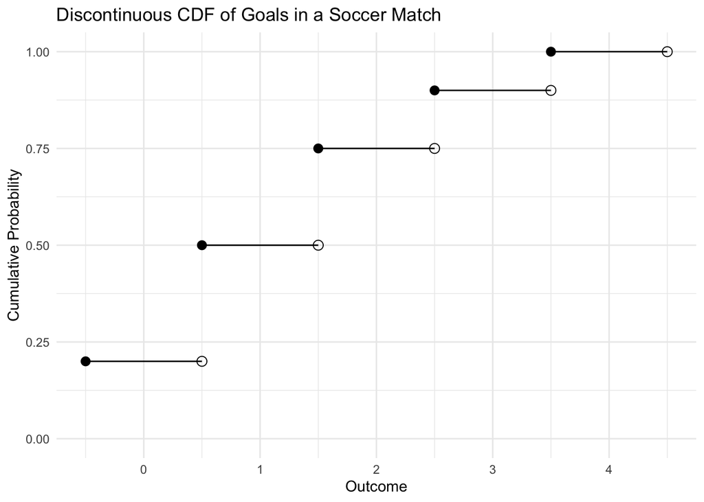

```r
# compute the cumulative probabilities (CDF)
scores$cumulative_probability <- cumsum(scores$probability)

# plot the CDF using ggplot2
ggplot(scores, aes(x = number_of_goals, y = cumulative_probability)) +
  # horizontal lines for steps
  geom_segment(
    aes(x = number_of_goals - 0.5, xend = number_of_goals + 0.5,
        y = cumulative_probability, yend = cumulative_probability),
    color = "black"
  ) +
  # filled points at the left end
  geom_point(
    aes(x = number_of_goals - 0.5, y = cumulative_probability),
    size = 3, color = "black", shape = 16  # filled circle
  ) +
  # hollow points at the right end
  geom_point(
    aes(x = number_of_goals + 0.5, y = cumulative_probability),
    size = 3, color = "black", shape = 1  # hollow circle
  ) +
  labs(
    title = "Discontinuous CDF of Goals in a Soccer Match",
    x = "Outcome",
    y = "Cumulative Probability"
  ) +
  theme_minimal() +
  scale_y_continuous(limits = c(0, 1))  # ensure y-axis spans from 0 to 1
```

## **Cvičení 4: Simulace výsledků testu se spojitým rozdělením**

Simulujte výsledky testu pro 500 studentů. Výsledky jsou normálně rozděleny s průměrem 75 a směrodatnou odchylkou 10.

1. Vypočítejte pravděpodobnost, že student získá více než 90 bodů.
2. Vykreslete hustotu pravděpodobnosti (PDF) výsledků.

```r
set.seed(42)
mean_score <- 75
sd_score <- 10
test_scores <- rnorm(500, mean = mean_score, sd = sd_score)

# calculate the probability of scoring above 90
prob_above_90 <- 1 - pnorm(90, mean = mean_score, sd = sd_score)
prob_above_90
```

```
## [1] 0.0668072
```

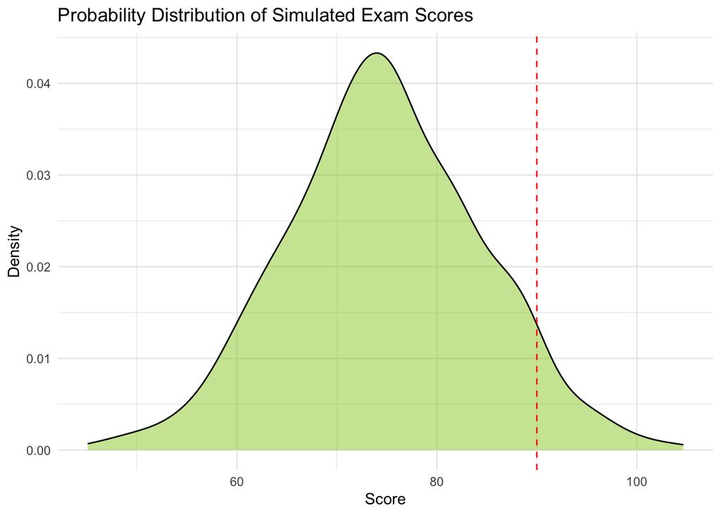

```r
# plot the PDF of the test scores
ggplot(data.frame(scores = test_scores), aes(x = scores)) +
  geom_density(fill = "yellowgreen", alpha = 0.5) +
  geom_vline(xintercept = 90, linetype = "dashed", color = "red") +
  labs(title = "Probability Distribution of Simulated Exam Scores",
       x = "Score",
       y = "Density") +
  theme_minimal()
```

## **Cvičení 5: Odhad CDF z empirických dat**

Použijte výsledky testu ze Cvičení 4, vypočítejte a vykreslete empirickou distribuční funkci (CDF). Odhadněte pravděpodobnost, že student získá méně než 60 bodů.

```r
set.seed(42)
# calculate the empirical CDF and the probability of scoring less than 60
test_scores_ecdf <- ecdf(test_scores)
prob_less_than_60 <- test_scores_ecdf(60)
prob_less_than_60
```

```
## [1] 0.06
```

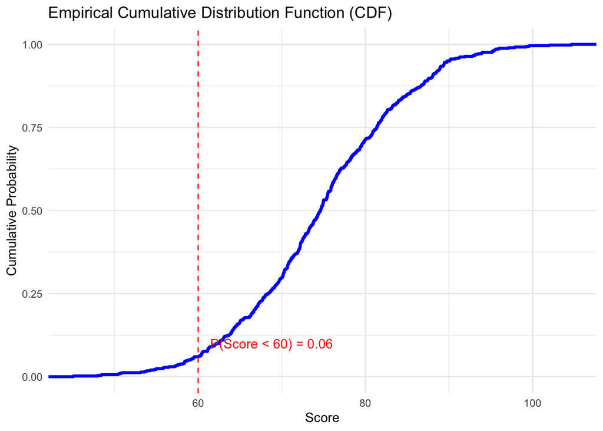

```r
# plot the empirical CDF
ggplot(data.frame(x = test_scores), aes(x)) +
  stat_ecdf(geom = "step", color = "blue", size = 1.2) +
  geom_vline(xintercept = 60, linetype = "dashed", color = "red") +
  annotate("text", x = 60, y = 0.1, label = paste("P(Score < 60) =", round(prob_less_than_60, 4)), color = "red", hjust = -0.1) +
  labs(title = "Empirical Cumulative Distribution Function (CDF)",
       x = "Score",
       y = "Cumulative Probability") +
  theme_minimal()
```

## **Cvičení 6: Vztah mezi PMF a očekávanou hodnotou**

Firma prodává produkt za 5 USD. Pravděpodobnost prodeje u jednoho zákazníka je 0,1 a kontaktuje 100 zákazníků.

1. Simulujte počet prodejů ze 100 kontaktů.
2. Vypočítejte očekávaný zisk z těchto prodejů.
3. Vykreslete PMF počtu prodejů.

```r
set.seed(42)
# parameters
n_customers <- 100    # number of customers contacted
p_sale <- 0.1         # probability of a sale

# simulate number of sales
sales <- rbinom(1, size = 100, prob = 0.1)
sales
```

```
## [1] 14
```

```r
# calculate the expected revenue
revenue <- sales * 5
revenue
```

```
## [1] 70
```

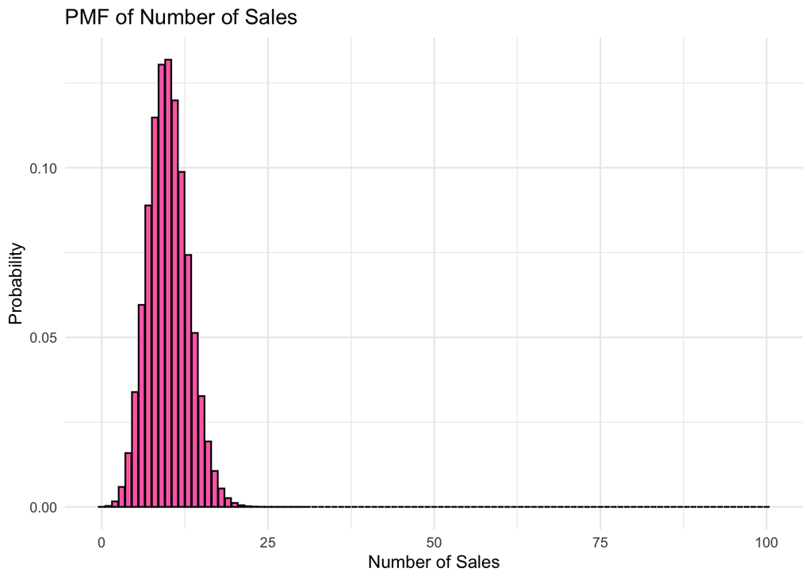

```r
# plot the PMF of the number of sales
pmf_data <- data.frame(sales = 0:100,
                       probability = dbinom(0:100, size = 100, prob = 0.1))

ggplot(pmf_data, aes(x = sales, y = probability)) +
  geom_bar(stat = "identity", fill = "hotpink1", color = "black") +
  labs(title = "PMF of Number of Sales",
       x = "Number of Sales",
       y = "Probability") +
  theme_minimal()
```

## **Cvičení 7: Porovnání dvou spojitých náhodných veličin**

Simulujte dvě spojité náhodné veličiny:

1. X ~ N(0, 1)
2. Y ~ N(3, 1.5)
3. Vykreslete hustoty pravděpodobnosti (PDF) obou veličin na jednom grafu.
4. Vypočítejte pravděpodobnost, že X > Y.

```r
set.seed(42)
library(dplyr)
```

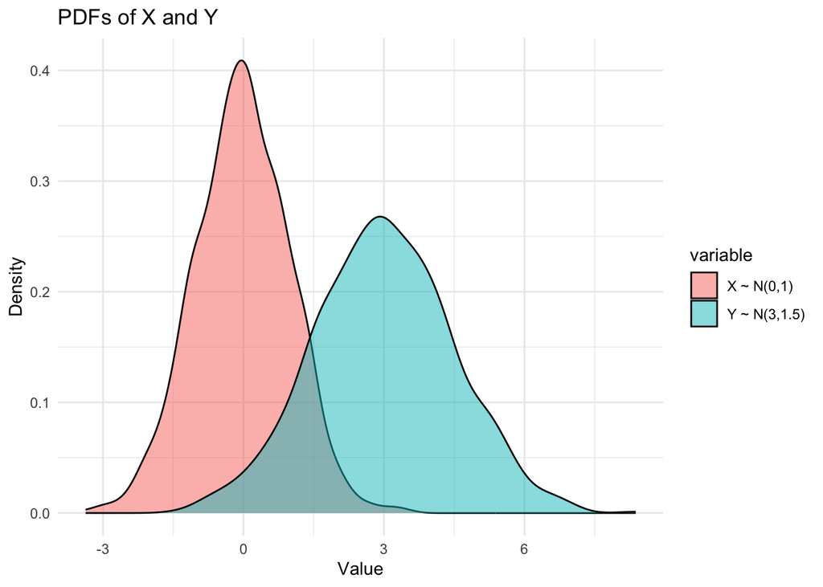

```r
library(tidyr)

# X ~ N(0, 1) and Y ~ N(3, 1.5)
n <- 1000
X <- rnorm(n, mean = 0, sd = 1)
Y <- rnorm(n, mean = 3, sd = 1.5)

# plot the PDFs of X and Y on the same plot
pdf_data <- data.frame(
  value = c(X, Y),
  variable = c(rep("X ~ N(0,1)", n), rep("Y ~ N(3,1.5)", n))
)

ggplot(pdf_data, aes(x = value, fill = variable)) +
  geom_density(alpha = 0.5) +
  labs(title = "PDFs of X and Y",
       x = "Value",
       y = "Density") +
  theme_minimal()
```

```r
# calculate the probability that X > Y
prob_X_greater_Y <- mean(X > Y)
prob_X_greater_Y
```

```
## [1] 0.051
```

## **Cvičení 8: Rovnoměrné rozdělení – náhodná procházka**

Vygenerujte 1000 kroků náhodné procházky, kde každý krok je náhodně zvolen z rovnoměrného rozdělení mezi -1 a 1.

1. Vykreslete trajektorii náhodné procházky.
2. Vypočítejte a vykreslete kumulativní součet kroků.

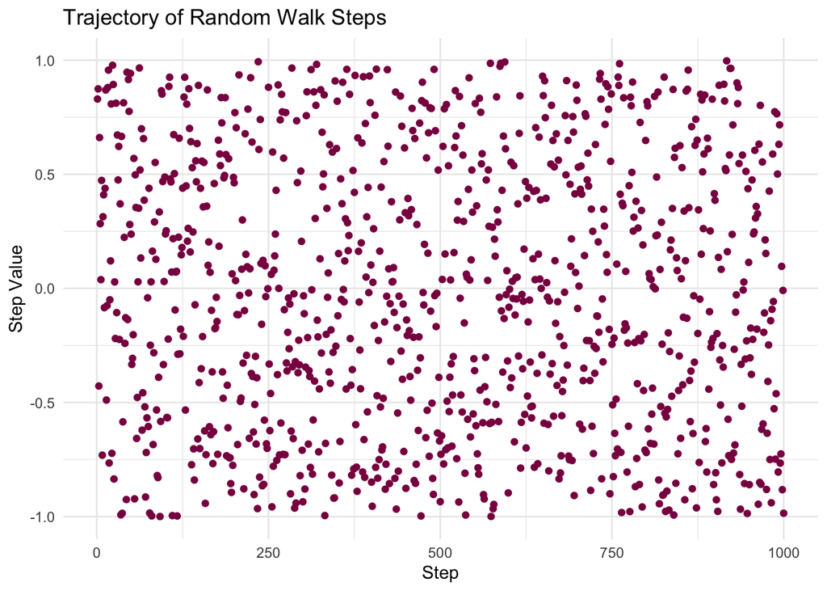

```r
set.seed(42)
n_steps <- 1000
steps <- runif(n_steps, min = -1, max = 1)

# calculate the cumulative sum (random walk)
random_walk <- cumsum(steps)

# plot the trajectory of the random walk
step_data <- data.frame(step = 1:n_steps, position = steps)
ggplot(step_data, aes(x = step, y = position)) +
  geom_point(color = "deeppink4") +
  labs(title = "Trajectory of Random Walk Steps",
       x = "Step",
       y = "Step Value") +
  theme_minimal()
```

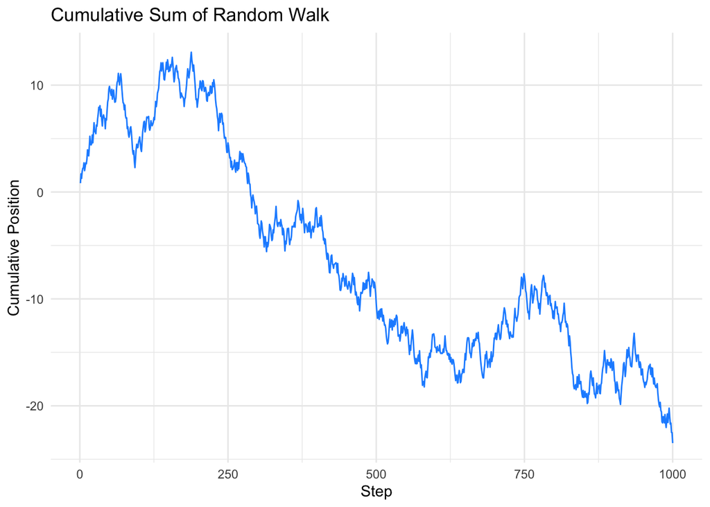

```r
# cumulative sum plot
walk_data <- data.frame(step = 1:n_steps, position = random_walk)
ggplot(walk_data, aes(x = step, y = position)) +
  geom_line(color = "dodgerblue") +
  labs(title = "Cumulative Sum of Random Walk",
       x = "Step",
       y = "Cumulative Position") +
  theme_minimal()
```